# Testing Out Pairwise Lingam

Zarrar Shehzad

07/14/2014

I haven’t done any filtering but I’m not sure if the simulation dataset came unfiltered?

# Setup

```r
library(plyr)
library(reshape)
```

```r
library(ggplot2)

source('~/Dropbox/Research/yale/causality_primer/lib/lingan/pwling.R')
upper   <- function(x) x[upper.tri(x)]

basedir <- "~/Dropbox/Research/yale/causality_primer/netsim"
nsubjs  <- 50
nsims   <- 28

# duration=mins; ts=secs; noise=%; hrf.std=s
df.specs<- read.csv(file.path(basedir, "data", "sim_specs.csv"), skip=2)
```

# Analysis

Here we calculate the direction of only the correct connections across the 28 simulations. Note that the speed of running each simulation for each subject and each of 7 methods is very fast.

```r
df.tprs <- ldply(1:nsims, function(simi) {
  cat("Running simulation", simi, "\n")

  print(system.time(subj.tprs <- ldply(1:nsubjs, function(subi) {
    ts    <- as.matrix(read.table(sprintf("%s/data/sim%02i/sub%02i_ts.txt", basedir, simi, subi)))
    net   <- as.matrix(read.table(sprintf("%s/data/sim%02i/sub%02i_net.txt", basedir, simi, subi)))
    diag(net) <- 0

    tprs  <- sapply(c(1,2,-3,3,-4,4,5), function(i) {
      #cat("\nmethod", i, "\n")
      dirmat <- pwling(t(ts), i, verbose=F)
      tpr <- mean(sign(dirmat[net!=0]) == 1)
      #fpr <- mean(sign(upper(dirmat)[upper(net)==0]) == 1)
      #c(tpr=tpr, fpr=fpr)
      return(tpr)
    })

    df <- data.frame(
      subject = rep(subi, length(tprs)),
      measure = c("EB", "Tanh", "Skew", "SkewCorr", "RSkew", "RSkewCorr", "DBSkew"),
      accuracy = tprs
    )

    return(df)
  })))

  subj.tprs$simulation <- simi

  return(subj.tprs)
})
```

```
## Running simulation 1
##    user  system elapsed
##   1.406   0.049   1.457
## Running simulation 2
##    user  system elapsed
##   4.143   0.044   4.187
## Running simulation 3
##    user  system elapsed
##   8.376   0.044   8.425
## Running simulation 4
##    user  system elapsed
##  79.779   0.098  79.928
## Running simulation 5
##    user  system elapsed
##   4.596   0.049   4.646
## Running simulation 6
##    user  system elapsed
##  13.642   0.063  13.708
## Running simulation 7
##    user  system elapsed
##  17.004   0.097  17.110
## Running simulation 8
##    user  system elapsed
##   1.342   0.039   1.381
## Running simulation 9
##    user  system elapsed
##  17.259   0.101  17.376
## Running simulation 10
##    user  system elapsed
##   1.339   0.038   1.377
## Running simulation 11
##    user  system elapsed
##   3.962   0.032   3.994
## Running simulation 12
##    user  system elapsed
##   4.163   0.039   4.202
## Running simulation 13
##    user  system elapsed
##   1.351   0.039   1.391
## Running simulation 14
```

[output cut: 29 more lines]

```
## Running simulation 24
##    user  system elapsed
##   1.328   0.046   1.373
## Running simulation 25
##    user  system elapsed
##   1.056   0.047   1.103
## Running simulation 26
##    user  system elapsed
##   0.932   0.035   0.969
## Running simulation 27
##    user  system elapsed
##   0.928   0.038   0.966
## Running simulation 28
##    user  system elapsed
##   1.053   0.045   1.099
```

```r
# Ensure factors are in order I gave
df.tprs$measure <- factor(df.tprs$measure, levels=c("EB", "Tanh", "Skew", "SkewCorr", "RSkew", "RSkewCorr", "DBSkew"),  labels=c("EB", "Tanh", "Skew", "SkewCorr", "RSkew", "RSkewCorr", "DBSkew"))
```

Get the mean accuracy across subjects for each simulation

```r
sum.tprs <- ddply(df.tprs, .(simulation, measure), colwise(mean))
sum.tprs <- sum.tprs[,-3]
sum.tprs$accuracy <- round(sum.tprs$accuracy*100)
sum.tprs <- cast(sum.tprs, simulation~measure, value="accuracy")
print(sum.tprs)
```

```
##    simulation EB Tanh Skew SkewCorr RSkew RSkewCorr DBSkew
## 1           1 56   73   77       58    85        66     53
## 2           2 59   69   83       57    87        61     56
## 3           3 52   69   80       53    86        57     53
## 4           4 53   66   77       55    82        58     54
## 5           5 59   89   98       68   100        76     58
## 6           6 73   88   97       61    99        66     57
## 7           7 74   98  100       78   100        86     75
## 8           8 57   63   78       50    82        54     51
## 9           9 74   91  100       48   100        57     44
## 10         10 59   60   74       52    77        56     48
## 11         11 57   67   80       53    85        60     54
## 12         12 54   68   80       51    82        57     52
## 13         13 45   52   61       51    63        52     57
## 14         14 68   74   74       57    85        65     50
## 15         15 68   61   91       38    92        44     42
## 16         16 49   65   79       53    83        55     55
## 17         17 67   81   90       62    97        67     59
## 18         18 66   74   78       56    89        63     54
## 19         19 71  100  100       62   100        75     65
## 20         20 95  100  100       72   100        76     64
## 21         21 57   72   77       57    83        65     54
## 22         22 29   22   37       43    33        40     42
## 23         23 60   69   72       70    82        76     68
## 24         24 68   62   65       54    72        66     54
## 25         25 58   62   72       53    80        60     51
## 26         26 59   63   66       54    70        59     51
## 27         27 68   74   76       57    84        67     52
## 28         28 70   78   80       61    87        68     55
```

# Plot

Plot each simulation separately

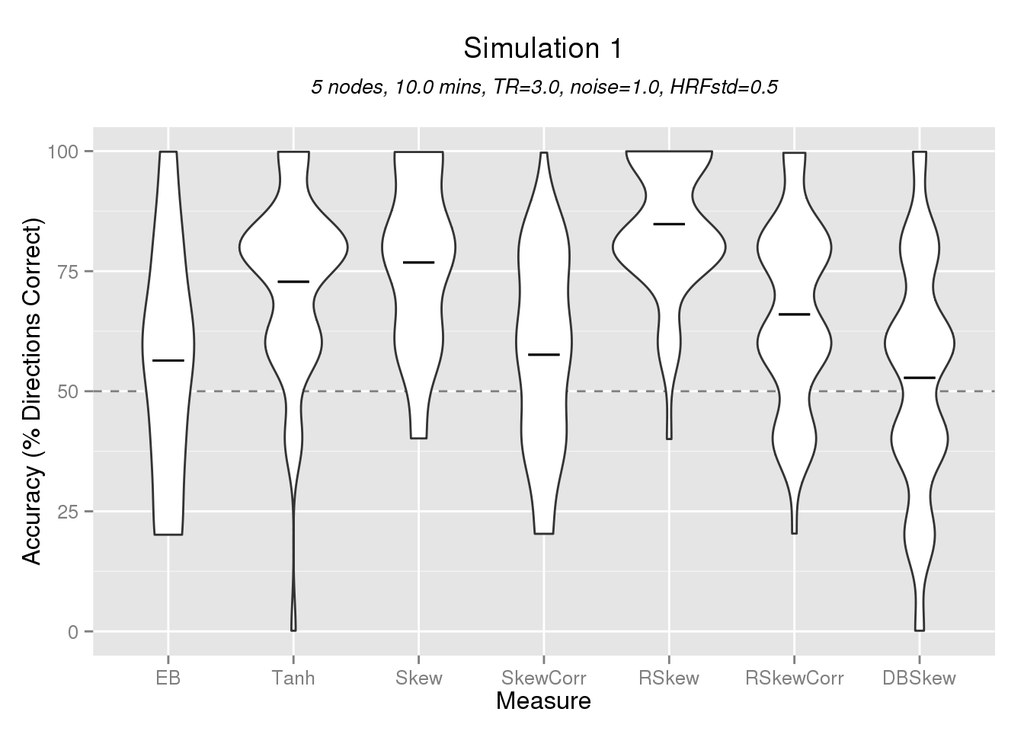

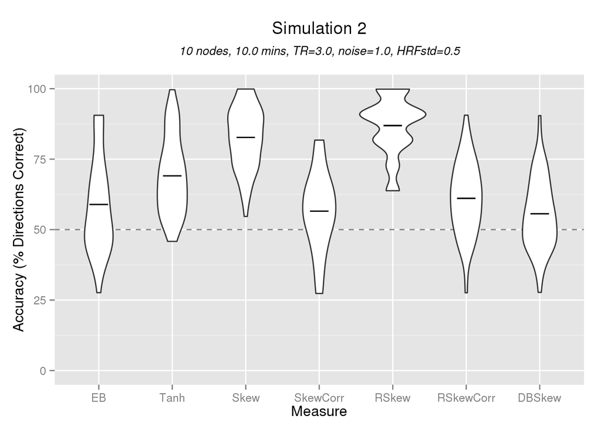

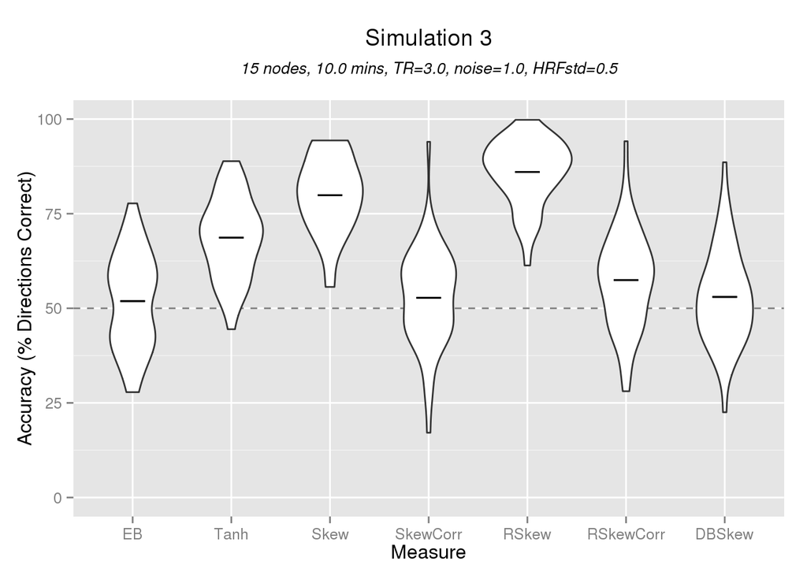

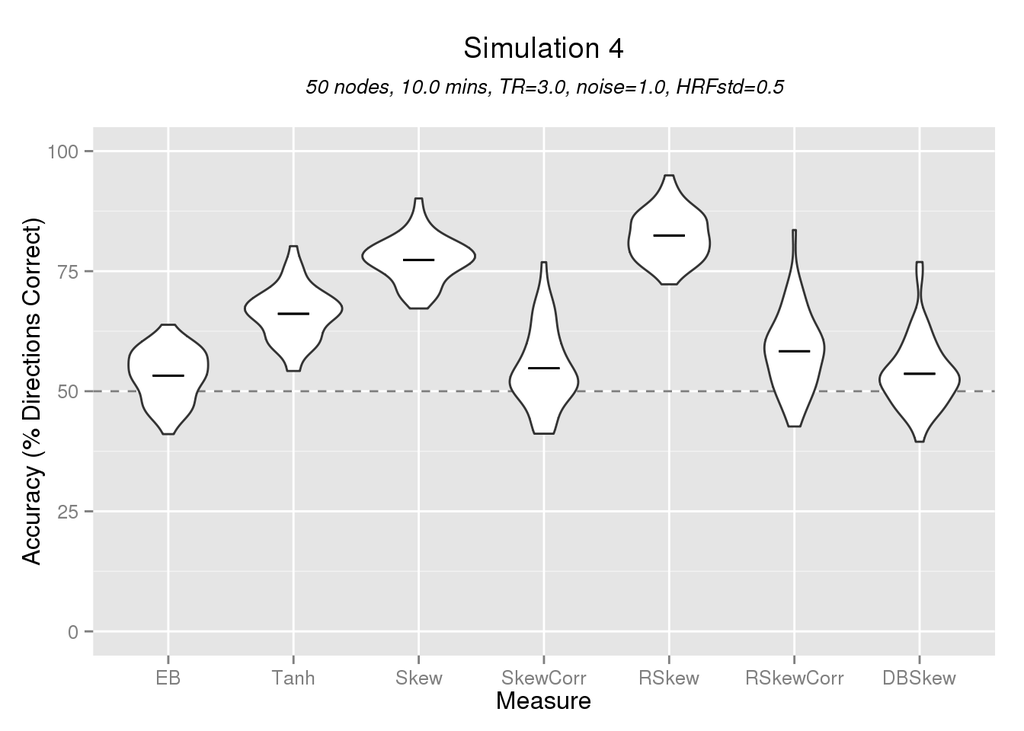

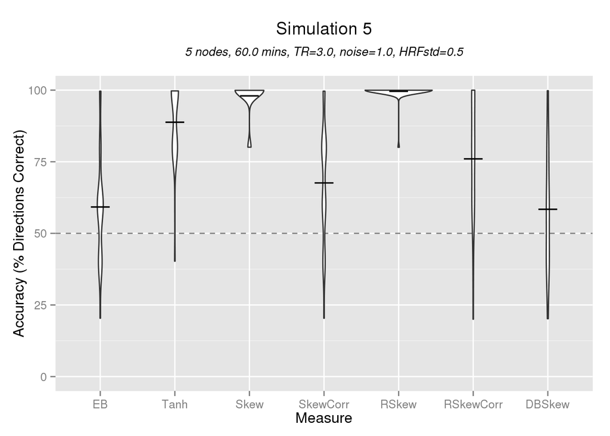

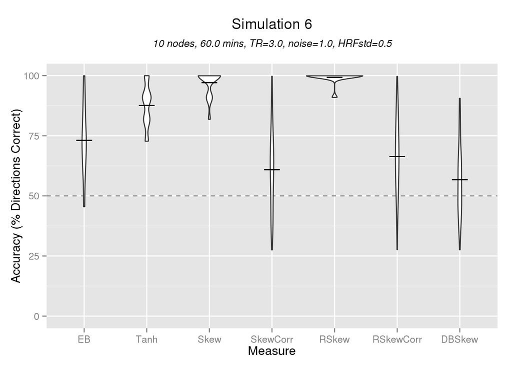

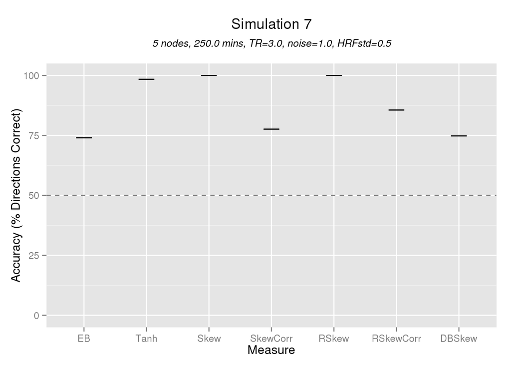

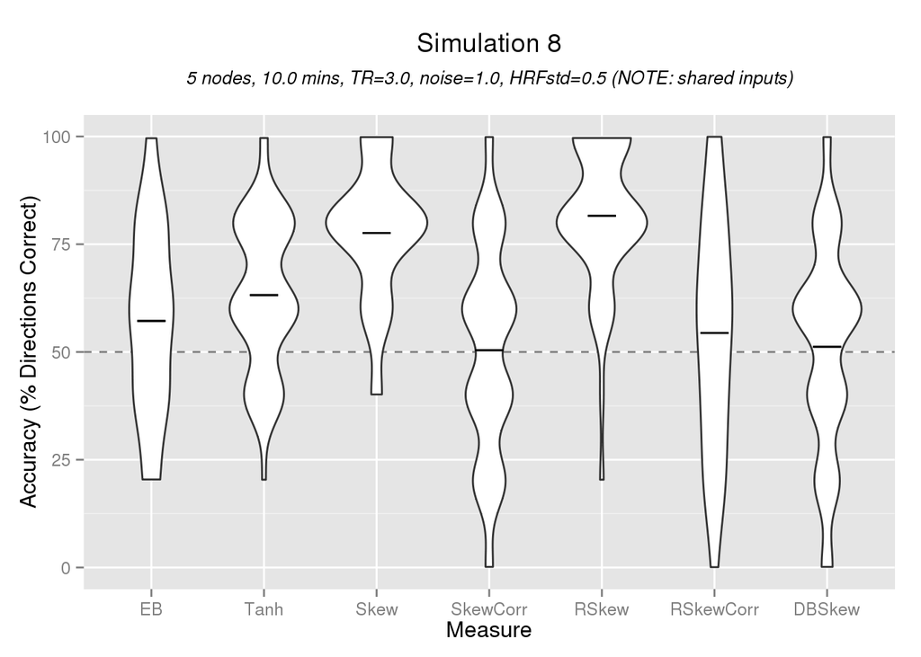

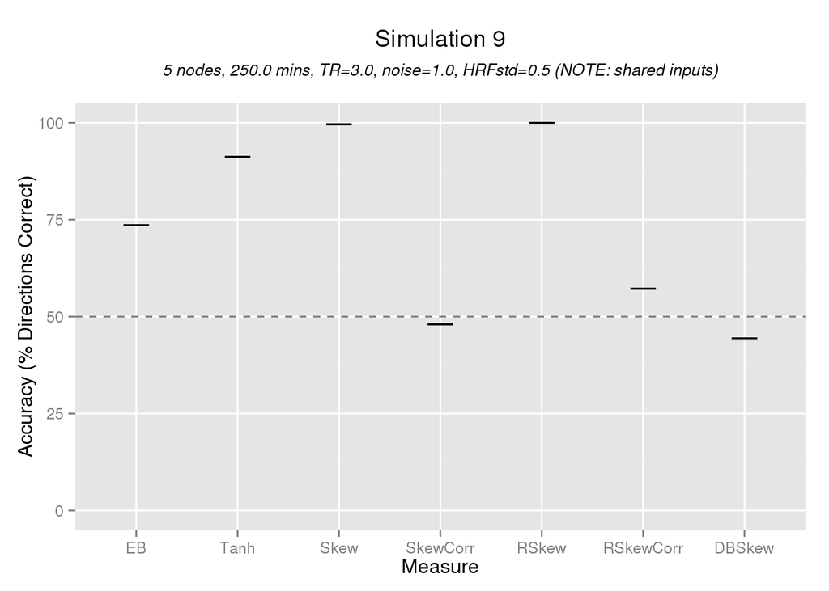

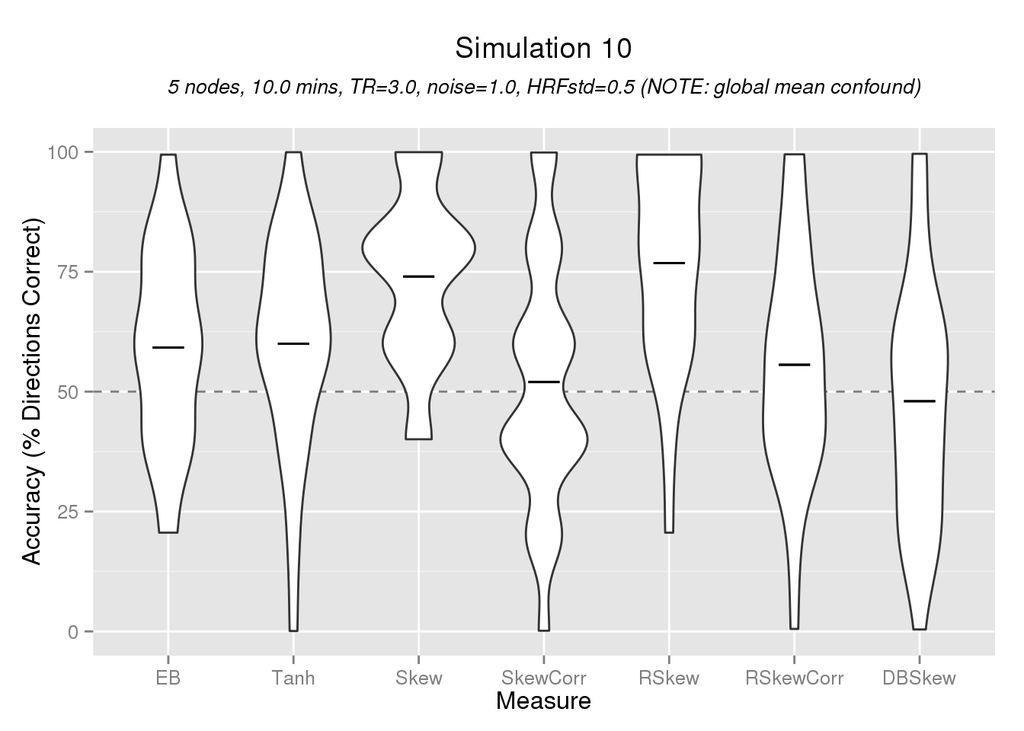

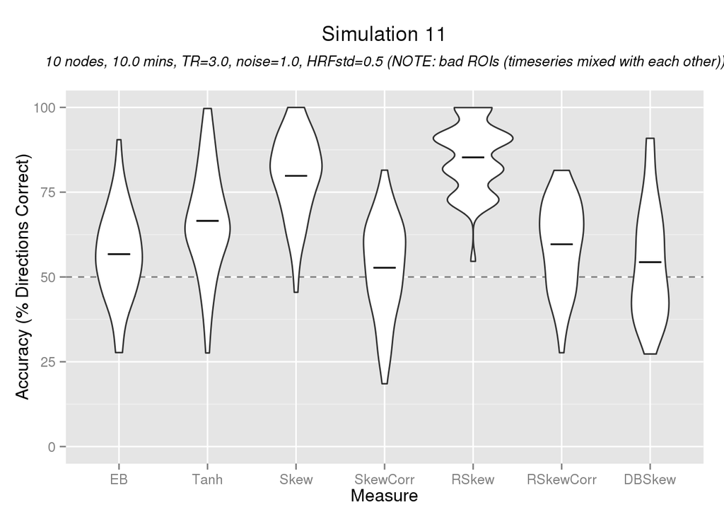

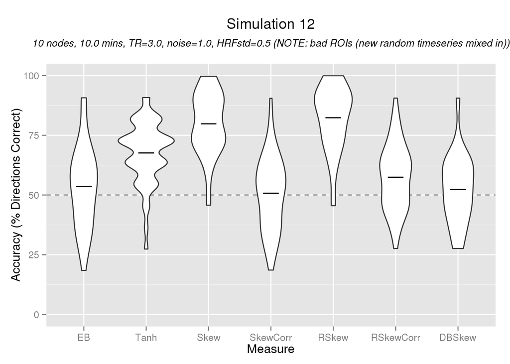

[16 more figures not shown]

```r
for (simi in 1:nsims) {
  rs            <- df.specs[simi,]
  plot.title    <- sprintf("Simulation %i", simi)
  plot.subtitle <- sprintf("%i nodes, %.1f mins, TR=%.1f, noise=%.1f, HRFstd=%.1f", rs$num.nodes, rs$duration, rs$tr, rs$noise, rs$hrf.std)
  if (rs$other != "") plot.subtitle <- sprintf("%s (NOTE: %s)", plot.subtitle, rs$other)

  sdf.tprs <- subset(df.tprs, simulation==simi)
  p <- ggplot(sdf.tprs, aes(measure, accuracy*100)) +
    geom_hline(yintercept=50, linetype=2, color="grey50") +
    geom_violin() +
    geom_errorbar(stat="hline", yintercept="mean", width=0.25, aes(ymax=..y..,ymin=..y..)) +
    xlab("Measure") +
    ylab("Accuracy (% Directions Correct)") +
    ylim(0,100) +
    ggtitle(bquote(atop(.(plot.title), atop(italic(.(plot.subtitle)), ""))))

  plot(p)
}
```

Finally, we can get an overview of the more high performing methods across the different simulations.

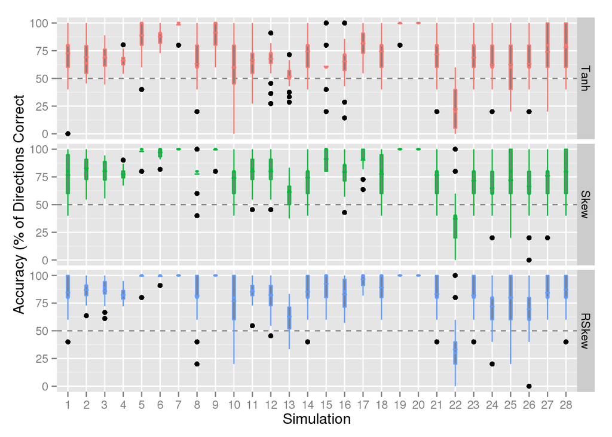

```r
df.tprs2 <- subset(df.tprs, measure %in% c("Tanh", "Skew", "RSkew"))

p <- ggplot(df.tprs2, aes(as.factor(simulation), accuracy*100, color=measure)) +
  geom_hline(yintercept=50, linetype=2, color="grey50") +
  #geom_point(position=position_jitter(width=0.1)) +
  geom_boxplot(width=.2, fill="gray50") +
  geom_errorbar(stat="hline", yintercept="mean", width=0.25, aes(ymax=..y..,ymin=..y..)) +
  facet_grid(measure~.) +
  xlab("Simulation") +
  ylab("Accuracy (% of Directions Correct") +
  theme(legend.position="none")
plot(p)
```

We can see from these summary plot that the three approaches do well on most simulations. The problematic simulations include:

- Simulation 8: shared inputs
- Simulation 10: global mean confound
- Simulation 13: backward connection
- Simulation 22: non-stationary connection strengths
- Simulation 24: only one strong external input
- Simulation 26: only 2.5mins and higher noise

Below, we rank each method by simulation to further distinguish the methods.

```r
mean.acc <- ddply(df.tprs2, .(simulation, measure), function(x) {
  c(accuracy=mean(x$accuracy))
})
rank.acc <- ddply(mean.acc, .(simulation), function(x) {
  c(measure=x$measure[which.max(x$accuracy)])
})
print(rank.acc)
```

```
##    simulation measure
## 1           1       5
## 2           2       5
## 3           3       5
## 4           4       5
## 5           5       5
## 6           6       5
## 7           7       3
## 8           8       5
## 9           9       5
## 10         10       5
## 11         11       5
## 12         12       5
## 13         13       5
## 14         14       5
## 15         15       5
## 16         16       5
## 17         17       5
## 18         18       5
## 19         19       3
## 20         20       2
## 21         21       5
## 22         22       3
## 23         23       5
## 24         24       5
## 25         25       5
## 26         26       5
## 27         27       5
## 28         28       5
```